# Regression

Anna Yeaton

Fall 2019

# Lab Section

In this lab, we will go over regression. We will be using the caret package in R. https://topepo.github.io/caret/train-models-by-tag.html

# Perfomance Metrics

## Residual

Deviation of the observed value to the estimated value (sample mean)
$$residual=y_i - \hat{y_i}$$
where $\hat{y_i}$ is the estimated value

## Mean Squared Error (MSE)

$$MSE=\frac{1}{n}\sum_{i=1}^{n}(y_i - \hat{y_i})^2$$

## Root Mean Squared Error (RMSE)

Same units as original data.

$$RMSE=\sqrt{MSE}$$

## L2 regularization : Ridge regression. Regularize by adding the sum of the coefficients, squared, to the function.

$$Ridge Regression=\sum_{i=1}^{n}(y_i - w_0 - \sum_{j=1}^{p}w_jx_{ij})^2 + \lambda\sum_{j=1}^p(w_j)^2$$

## L1 regularization : Lasso Regression. Regularize by adding the sum of the absolute value of the coefficients to the model. Coefficient estimates may be pushed to zero – Lasso can perform variable selection

$$Lasso Regression=\sum_{i=1}^{n}(y_i - w_0 - \sum_{j=1}^{p}w_jx_{ij})^2 + \lambda\sum_{j=1}^p|w_j|$$

### The broad steps of Machine learning in R.

1. Split the data into training and test. Set test aside.
2. Fit a good model to the training data.
3. See how your model did on the training data.
4. Test how your model performs on the test data.

# Regression

1. Split data into training and test set (75% in train set, 25% in test set)

```r
# view structure of data

str(airquality) # all numerical values, but missing values present
```

```
## 'data.frame':    153 obs. of  6 variables:
##  $ Ozone  : int  41 36 12 18 NA 28 23 19 8 NA ...
##  $ Solar.R: int  190 118 149 313 NA NA 299 99 19 194 ...
##  $ Wind   : num  7.4 8 12.6 11.5 14.3 14.9 8.6 13.8 20.1 8.6 ...
##  $ Temp   : int  67 72 74 62 56 66 65 59 61 69 ...
##  $ Month  : int  5 5 5 5 5 5 5 5 5 5 ...
##  $ Day    : int  1 2 3 4 5 6 7 8 9 10 ...
```

```r
# investigate if missing values in relevant columns
sum(is.na(airquality$Temp))
```

```
## [1] 0
```

```r
sum(is.na(airquality$Wind))
```

```
## [1] 0
```

```r
# missing values not relevant as they are not in Temp or Wind

# set a random seed for reproducibility

set.seed(101)

# split data

training_size <- floor(0.75 * nrow(airquality))
training_index <- sample(seq_len(nrow(airquality)), size = training_size)

train_regression <- airquality[training_index, ]
test_regression <- airquality[-training_index, ]

nrow(train_regression) # 114 rows - confirms split is correct
```

```
## [1] 114
```

```r
nrow(test_regression) # 39 rows
```

```
## [1] 39
```

```r
# view split data
train_regression
```

|  | Ozone | Solar.R | Wind | Temp | Month | Day |
| --- | --- | --- | --- | --- | --- | --- |
| 57 | NA | 127 | 8.0 | 78 | 6 | 26 |
| 7 | 23 | 299 | 8.6 | 65 | 5 | 7 |
| 108 | 22 | 71 | 10.3 | 77 | 8 | 16 |
| 99 | 122 | 255 | 4.0 | 89 | 8 | 7 |
| 38 | 29 | 127 | 9.7 | 82 | 6 | 7 |
| 45 | NA | 332 | 13.8 | 80 | 6 | 14 |
| 86 | 108 | 223 | 8.0 | 85 | 7 | 25 |
| 49 | 20 | 37 | 9.2 | 65 | 6 | 18 |
| 91 | 64 | 253 | 7.4 | 83 | 7 | 30 |
| 79 | 61 | 285 | 6.3 | 84 | 7 | 18 |

[output cut: 104 more lines]

```r
test_regression
```

|  | Ozone | Solar.R | Wind | Temp | Month | Day |
| --- | --- | --- | --- | --- | --- | --- |
| 5 | NA | NA | 14.3 | 56 | 5 | 5 |
| 13 | 11 | 290 | 9.2 | 66 | 5 | 13 |
| 16 | 14 | 334 | 11.5 | 64 | 5 | 16 |
| 19 | 30 | 322 | 11.5 | 68 | 5 | 19 |
| 21 | 1 | 8 | 9.7 | 59 | 5 | 21 |
| 23 | 4 | 25 | 9.7 | 61 | 5 | 23 |
| 30 | 115 | 223 | 5.7 | 79 | 5 | 30 |
| 32 | NA | 286 | 8.6 | 78 | 6 | 1 |
| 33 | NA | 287 | 9.7 | 74 | 6 | 2 |
| 34 | NA | 242 | 16.1 | 67 | 6 | 3 |

[output cut: 29 more lines]

### Linear Regression

- Assumes a linear relationship.
- Independent variables should not be correlated (no mulitcollinearity)
- The number of observations should be greater than the number of independent variables.

$$RSS=\sum(y_i - \hat{y_i})^2$$
We will predict the response of the Temperature based on Wind.

This is the data we will fit a linear model to.

```r
# ggplot(data = train_regression) +
#   geom_point(aes(x=Wind, y=Temp)) +
#   theme_bw()
```

2. Create and fit a linear model to predict Temperature from Wind using the training set

```r
#help(train)

linear_regression <- train(Temp ~ Wind, data = train_regression, method = "lm")
```

3. Vizualize how your model performed on the train data by plotting the regression line on top of the train data points.

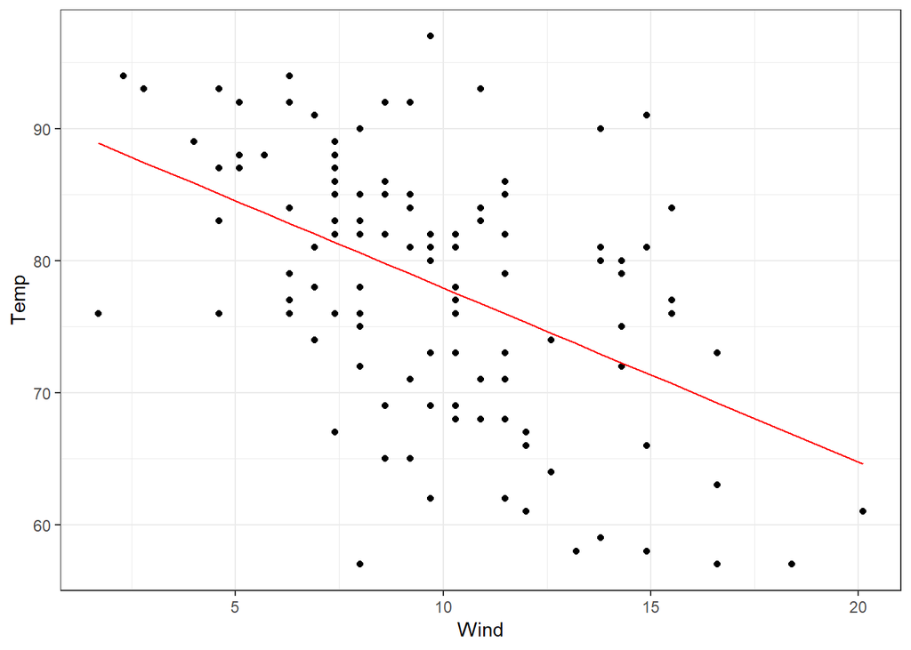

```r
ggplot(data=train_regression, aes(x=Wind, y=Temp)) +
geom_point() +
geom_line(aes(y=fitted(linear_regression)), colour = 'red') +
theme_bw()
```

```r
# plot shows reasonable distribution of residuals (both long and short) i.e. approximately equal variance around the regression line. Therefore, model has performed reasonably well, when assessed visually.
```

4. Explore how the model performs on the test data. For Linear Regression:
- The residuals should be close to zero.
- There should be equal variance around the regression line (homoscedasticity).
- Residuals should be normally distributed.
- Independent variables and residuals should not be correlated.

4 a) See how the model performs on the test data

```r
#help(predict)

linear_predict <- predict(linear_regression, newdata=test_regression)
```

4 b) Look at the residuals. Are they close to zero?

```r
#look at the median residual value. Close to zero is best
#help(summary)

summary(linear_regression) # median residual value is 1.645
```

```
##
## Call:
## lm(formula = .outcome ~ ., data = dat)
##
## Residuals:
##     Min      1Q  Median      3Q     Max
## -23.581  -6.132   1.645   6.028  19.522
##
## Coefficients:
##             Estimate Std. Error t value Pr(>|t|)
## (Intercept)  91.1348     2.3769  38.342  < 2e-16 ***
## Wind         -1.3193     0.2289  -5.764 7.35e-08 ***
## ---
## Signif. codes:  0 '***' 0.001 '**' 0.01 '*' 0.05 '.' 0.1 ' ' 1
##
## Residual standard error: 8.514 on 112 degrees of freedom
## Multiple R-squared:  0.2288, Adjusted R-squared:  0.2219
## F-statistic: 33.23 on 1 and 112 DF,  p-value: 7.354e-08
```

4 c) Plot predicted temperature vs observed temperature. A strong model should show a strong correlation

```r
# make a data frame first, for ease of comparison
results <- cbind(linear_predict,test_regression$Temp)
colnames(results) <- c('predicted temperature','observed temperature')
results <- as.data.frame(results)
results
```

|  | predicted temperature | observed temperature |
| --- | --- | --- |
| 5 | 72.26944 | 56 |
| 13 | 78.99764 | 66 |
| 16 | 75.96335 | 64 |
| 19 | 75.96335 | 68 |
| 21 | 78.33801 | 59 |
| 23 | 78.33801 | 61 |
| 30 | 83.61503 | 79 |
| 32 | 79.78919 | 78 |
| 33 | 78.33801 | 74 |
| 34 | 69.89478 | 67 |

[output cut: 29 more lines]

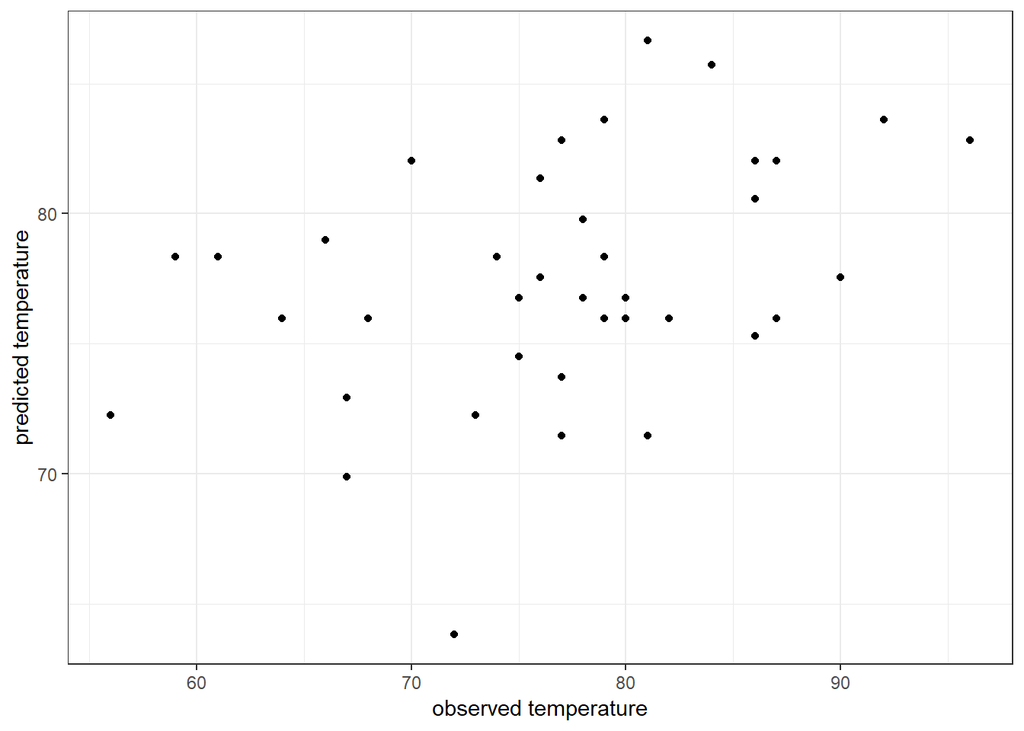

```r
# plot
ggplot(data=results, aes(x=results$`observed temperature`, y=results$`predicted temperature`)) +
geom_point() +
labs(x = "observed temperature", y = "predicted temperature") +
theme_bw()
```

```r
# plot shows some degree of correlation between observed and predicted temperature values
```

4 d) Visualize the predicted values in relation to the real data points. Look for homoscedasticity

```r
# Extract coefficients from the model

intercept <- linear_regression$finalModel$coefficients[1]
slope <- linear_regression$finalModel$coefficients[2]

intercept # 91.13478
```

```
## (Intercept)
##    91.13478
```

```r
slope # -1.319254
```

```
##      Wind
## -1.319254
```